# atividade4

2025-06-11

# ACESSO A BANCOS DE DADOS ABERTOS: Repositório de dados de ocorrências de espécies.

Atividade: acessar os repositórios do GBIF e OBIS, inspecionar os dados baixados, avaliar sua qualidade e fazer mapas de ocorrências da espécie selecionada.

Obs. GBIF engloba espécies terrestres e aquáticas, enquanto OBIS engloba apenas espécies marinhas.

Espécie marinha selecionada: Paracanthus hepatus.

# Pacotes necessários

tidyverse dplyr CoordinateCleaner bcd ggplot2 ggmap maps mapdata rgbif robis

```r
library("tidyverse")
library("dplyr")
library("CoordinateCleaner")
library("ggplot2")
library("ggmap")
library("maps")
library(mapdata)
library(rgbif)
library(robis)
```

# Baixar ocorrências (dados) e checar dimensões dos mesmos:

```r
dori_gbif <- occ_data(scientificName = "Paracanthurus hepatus",
                      hasCoordinate = TRUE,
                      hasGeospatialIssue=FALSE)

dim(dori_gbif)
```

```r
dim(dori_gbif$data)
```

```
## [1] 500 148
```

# Checar campos das variáveis disponíveis relacionadas a P. hepatus:

As variáveis podem ser utilizadas para filtrar as ocorrências de acordo com o objetivo, além de fornecerem diversos dados a respeito das ocorrências.

```r
dori_gbif$data %>% names
```

```
##   [1] "key"
##   [2] "scientificName"
##   [3] "decimalLatitude"
##   [4] "decimalLongitude"
##   [5] "issues"
##   [6] "datasetKey"
##   [7] "publishingOrgKey"
##   [8] "installationKey"
##   [9] "hostingOrganizationKey"
##  [10] "publishingCountry"
##  [11] "protocol"
##  [12] "lastCrawled"
##  [13] "lastParsed"
##  [14] "crawlId"
##  [15] "basisOfRecord"
```

[output cut: 133 more lines]

# Problemas reportados: coluna ‘issues’

A coluna indica os problemas já identificados pelo validador automático do repositório. Para checar os ‘issues’ indicados na base baixada, é necessário utilizar a função strsplit para individualizar os issues e poder conferí-los, pois algumas ocorrências possuem múltiplos problemas.

Para checar problemas reportados:

```r
issues_gbif <- dori_gbif$data$issues %>%
  unique() %>%
  strsplit(., "[,]") %>%
  unlist()

gbif_issues() %>%
  data.frame() %>%
  filter(code %in% issues_gbif)
```

```
##        code                                            issue
## 1       cdc               CONTINENT_DERIVED_FROM_COORDINATES
## 2     conti                                CONTINENT_INVALID
## 3    cdreps               COORDINATE_REPROJECTION_SUSPICIOUS
## 4   cdround                               COORDINATE_ROUNDED
## 5      cudc                 COUNTRY_DERIVED_FROM_COORDINATES
## 6       cum                                 COUNTRY_MISMATCH
## 7    gass84                     GEODETIC_DATUM_ASSUMED_WGS84
## 8    gdativ                           GEODETIC_DATUM_INVALID
## 9     rdatm                           RECORDED_DATE_MISMATCH
## 10 refuriiv                           REFERENCES_URI_INVALID
## 11    osiic OCCURRENCE_STATUS_INFERRED_FROM_INDIVIDUAL_COUNT
## 12  colmafu                           COLLECTION_MATCH_FUZZY
## 13  colmano                            COLLECTION_MATCH_NONE
## 14  incomis                  INSTITUTION_COLLECTION_MISMATCH
```

[output cut: 36 more lines]

Nenhum issue parece invalidar as ocorrências, por enquanto.

Prosseguimos selecionando algumas variáveis que serão úteis para a validação dos dados e futuras análises, como: coordenadas, profundidade, nome da base de dados etc.

```r
dori_gbif1 <- dori_gbif$data %>%
  dplyr::select(scientificName, acceptedScientificName, decimalLatitude, decimalLongitude,
         issues, waterBody, basisOfRecord, occurrenceStatus, rightsHolder,
         datasetName, recordedBy, depth, locality, habitat)
```

```r
dori_gbif1 <- dori_gbif$data %>%
  dplyr::select(scientificName, acceptedScientificName, decimalLatitude, decimalLongitude,
         issues, waterBody, basisOfRecord, occurrenceStatus, rightsHolder,
         datasetName, recordedBy, depth, locality, habitat)
```

Para identificar todos os valores únicos presentes nos dados, vamos aplicar a função unique a cada coluna com um loop na função lapply.

```r
# checar niveis dos fatores
lapply(dori_gbif1, unique)
```

```
## $scientificName
## [1] "Paracanthurus hepatus (Linnaeus, 1766)"
## [2] "BOLD:AAC3227"
##
## $acceptedScientificName
## [1] "Paracanthurus hepatus (Linnaeus, 1766)"
## [2] "BOLD:AAC3227"
##
## $decimalLatitude
##   [1]  -4.659287  -4.659753   4.532800  -0.533344 -22.494511 -24.114004
##   [7]  -8.346364 -22.494282  -5.828054 -17.610468  -4.745790  12.047721
##  [13]  16.511527 -30.205483  13.522559  -4.340387   0.350650 -28.611592
##  [19]  -0.561889  -5.771052  -1.832513  -1.837575  -0.819800 -29.929429
##  [25]   3.466667 -24.113883  13.438669  13.438930   4.601751  22.638717
##  [31] -24.114176  -2.195210 -22.454517   1.766050 -21.342338 -29.928547
```

[output cut: 689 more lines]

#Problemas não reportados Processo de checagem mais fina que não é realizada pelo algoritmo devido sua limitação de programação.

Inicialmente, podemos verificar se as coordenadas são válidas (e.g., latitudes > 90 ou longitude > 180) utilizando funções dos pacotes CoordinateCleaner e bcd. Clicando nos links dos pacotes vocês podem checar diversas outras funcionalidades oferecidas.

Para checar coordenadas válidas:

```r
library(bdc)
library(CoordinateCleaner)

check_pf <-
  bdc::bdc_coordinates_outOfRange(
    data = dori_gbif1,
    lat = "decimalLatitude",
    lon = "decimalLongitude")
```

```
##
## bdc_coordinates_outOfRange:
## Flagged 0 records.
## One column was added to the database.
```

Para checar coordenadas válidas e próximas a capitais (muitas vezes as coordenadas são erroneamente associadas a capitais dos países):

```r
cl <- dori_gbif1 %>%
  CoordinateCleaner::clean_coordinates(species = "acceptedScientificName",
                                       lat = "decimalLatitude",
                                       lon = "decimalLongitude",
                                       tests = c("capitals",
                                                 "centroids","equal",
                                                 "gbif", "institutions",
                                                 "outliers", "seas",
                                                 "zeros"))
```

```
## Testing coordinate validity
```

```
## Flagged 0 records.
```

```
## Testing equal lat/lon
```

```
## Flagged 0 records.
```

```
## Testing zero coordinates
```

```
## Flagged 0 records.
```

```
## Testing country capitals
```

```
## Flagged 17 records.
```

```
## Testing country centroids
```

```
## Flagged 2 records.
```

```
## Testing sea coordinates
```

```
## Flagged 465 records.
```

```
## Testing geographic outliers
```

```
## Flagged 0 records.
```

```
## Testing GBIF headquarters, flagging records around Copenhagen
```

```
## Flagged 0 records.
```

```
## Testing biodiversity institutions
```

```
## Flagged 0 records.
```

```
## Flagged 465 of 500 records, EQ = 0.93.
```

# Verificar visualmente coordenadas com flags:

O próximo passo é para gerar gráficos com as coordenadas associadas a espécie alvo para conferir os alertas - flags - indicados pelas funções.

1. Capitais (padrão é um raio de 10km): Não tivemos nenhuma coordenada inválida, mas algumas ocorrências parecem estar muito próximas a capitais. No entanto, todas as capitais estão em terra e, nesse caso, temos que investigar se as ocorrências estão em terra (lembre-se a Dori vive no mar!) ou apenas próximas a países insulares.

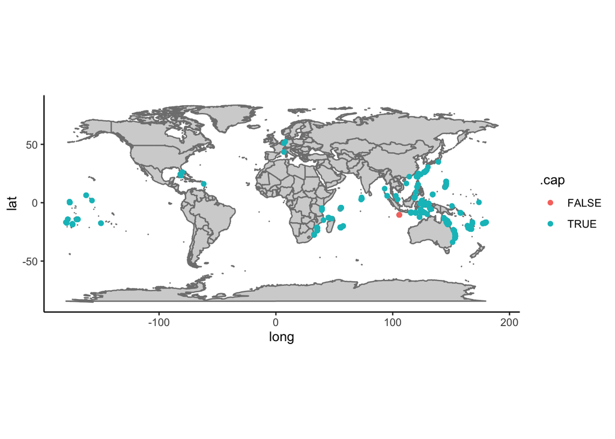

```r
ggplot() +
  borders("world", fill = "lightgray") +
  geom_point(data = cl, aes(x = decimalLongitude, y = decimalLatitude, color = `.cap`)) +
  coord_quickmap() +
  theme_classic()
```

2. Pontos no mar

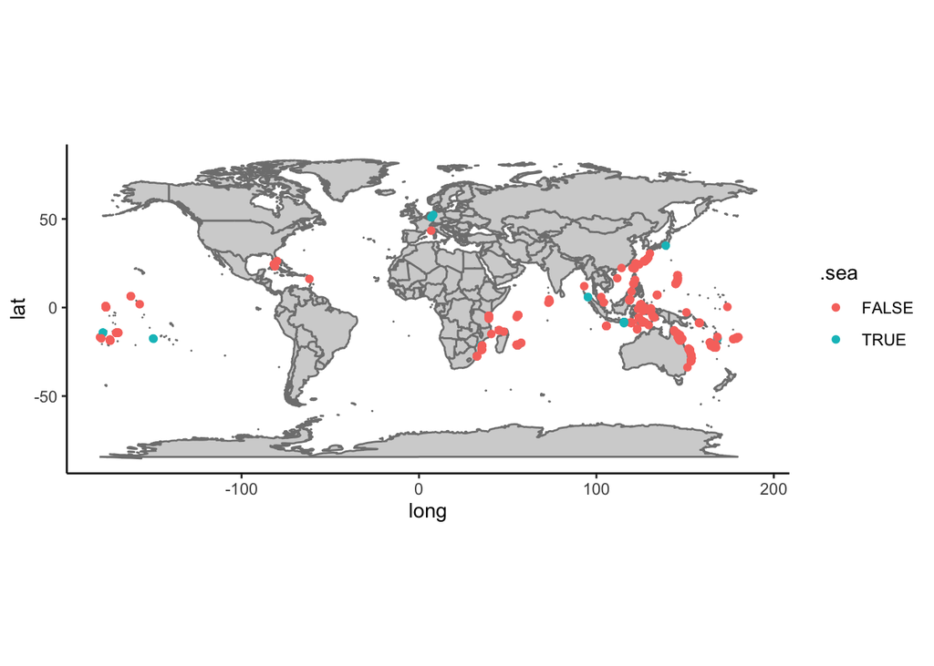

```r
ggplot() +
  borders("world", fill = "lightgray") +
  geom_point(data = cl, aes(x = decimalLongitude, y = decimalLatitude, color = `.sea`)) +
  coord_quickmap() +
  theme_classic()
```

# Checar distribuição das ocorrências

Excluir dados em terra: Checar a distribuição das ocorrências em relação às regiões oceanográficas indicadas nos dados (waterBody). Isso vale apenas para o OBIS.

Investigar níveis suspeitos:

```r
dori_gbif1 %>%
  distinct(waterBody) %>%
  pull()
```

```
##  [1] NA                    "North Pacific Ocean" "Celebes Sea"
##  [4] "Pacific Ocean"       "Flores Sea"          "South Pacific Ocean"
##  [7] "Caribbean Sea"       "Gulf of Mexico"      "Atlantic Ocean"
## [10] "Verde Island"
```

Função waterBody

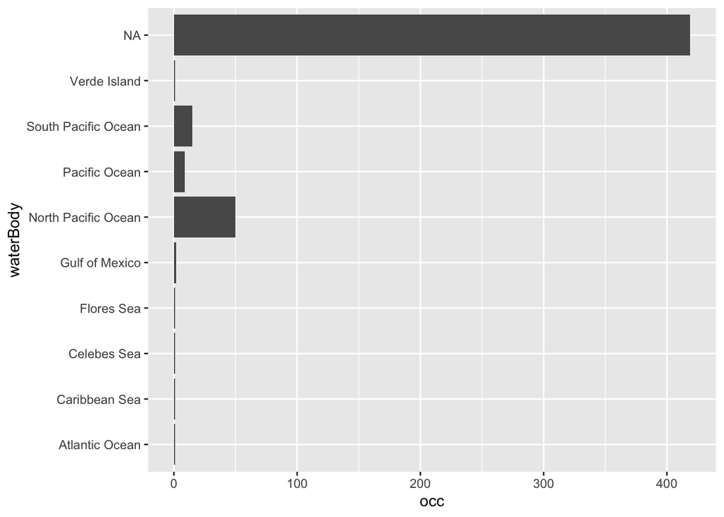

```r
dori_gbif1 %>%
  group_by(waterBody) %>%
  summarise(occ = length(scientificName)) %>%
  ggplot(aes(occ, y=waterBody)) +
    geom_bar(stat = 'identity')
```

Aparentemente esta espécie tem sido reportada no mundo todo, mas podemos acessar bancos de dados especializados para checar estas informações:No caso de peixes (Osteichthyes e Chondrichthyes) o ‘FishBase’ é a fonte mais atualizada de informações deste grupo.

Depois desta confirmação, podemos suspeitar das ocorrências indicadas no Atlântico e, o tratamento mais rigoroso é a exclusão de qualquer ocorrência suspeita.

Fontes das regiões erradas

```r
dori_gbif1 %>%
  filter(waterBody %in% c("Atlantic Ocean", "Carribean", "Royal Caribbean", "Carribean Sea", "Bonaire")) %>%
  distinct(datasetName)
```

```
## # A tibble: 1 × 1
##   datasetName
##   <chr>
## 1 Diveboard - Scuba diving citizen science
```

Alguma característica destas ocorrências do Atlântico podem dar pistas de como continuar filtrando os resultados. Neste caso, abaixo podemos ver que, ao investigarmos um programa de ciência de identificação realizada por mergulhadores amadores, notamos que este concentra a maior parte das suspeitas. Assim, é melhor ser conservador e remover todas as ocorrências associadas a tal programa.

```r
dori_gbif1 <- dori_gbif1 %>%
  filter(!waterBody %in% c("Atlantic Ocean", "Carribean", "Royal Caribbean", "Carribean Sea", "Bonaire"))
```

```r
dori_gbif1 %>%
  filter(datasetName %in% c("Diveboard - Scuba diving citizen science")) %>%
  data.frame()
```

```
##                           scientificName                 acceptedScientificName
## 1 Paracanthurus hepatus (Linnaeus, 1766) Paracanthurus hepatus (Linnaeus, 1766)
## 2 Paracanthurus hepatus (Linnaeus, 1766) Paracanthurus hepatus (Linnaeus, 1766)
## 3 Paracanthurus hepatus (Linnaeus, 1766) Paracanthurus hepatus (Linnaeus, 1766)
## 4 Paracanthurus hepatus (Linnaeus, 1766) Paracanthurus hepatus (Linnaeus, 1766)
## 5 Paracanthurus hepatus (Linnaeus, 1766) Paracanthurus hepatus (Linnaeus, 1766)
## 6 Paracanthurus hepatus (Linnaeus, 1766) Paracanthurus hepatus (Linnaeus, 1766)
##   decimalLatitude decimalLongitude     issues      waterBody     basisOfRecord
## 1         4.10933         118.6250 cdc,cdreps    Celebes Sea HUMAN_OBSERVATION
## 2        -8.40000         119.3500 cdc,cdreps     Flores Sea HUMAN_OBSERVATION
## 3        16.13510         -61.7710 cdc,cdreps  Caribbean Sea HUMAN_OBSERVATION
## 4        23.21210         -81.1858 cdc,cdreps Gulf of Mexico HUMAN_OBSERVATION
## 5        24.45500         -81.8583     cdreps Gulf of Mexico HUMAN_OBSERVATION
## 6        13.52280         120.9930 cdc,cdreps   Verde Island HUMAN_OBSERVATION
##   occurrenceStatus rightsHolder                              datasetName
## 1          PRESENT    Diveboard Diveboard - Scuba diving citizen science
## 2          PRESENT    Diveboard Diveboard - Scuba diving citizen science
## 3          PRESENT    Diveboard Diveboard - Scuba diving citizen science
## 4          PRESENT    Diveboard Diveboard - Scuba diving citizen science
## 5          PRESENT    Diveboard Diveboard - Scuba diving citizen science
## 6          PRESENT    Diveboard Diveboard - Scuba diving citizen science
##            recordedBy  depth                           locality habitat
## 1      Thomas Chardon 11.745                    Hanging Gardens    <NA>
## 2 Sebastien Rezzonico 12.540 Crystal Rock, Komodo National Park    <NA>
## 3               Marie 10.770                           Aquarium    <NA>
## 4        David Bishop 10.000                    Claraboyas Reef    <NA>
## 5               Jyore  5.330                    Rock Key (Reef)    <NA>
## 6    Christina Estrup 14.480                          The Atoll    <NA>
```

Filtrar todas do dataset suspeito

```r
dori_gbif_noDiveboard <- dori_gbif1 %>%
  filter(!datasetName %in% c("Diveboard - Scuba diving citizen science"))
```

Agora não temos mais nenhuma ocorrência no Atlântico, mas ainda existem algumas suspeitas no Mediterrâneo, Mar do Norte e um ponto ao norte no Japão, pois P. hepatus é uma espécie tropical!

Excluindo coordenadas mais boreais:

```r
dori_gbif_noDiveboard %>%
  filter(decimalLatitude > 25) %>%
  arrange(-decimalLatitude) %>%
  data.frame()
```

```
##                            scientificName
## 1  Paracanthurus hepatus (Linnaeus, 1766)
## 2  Paracanthurus hepatus (Linnaeus, 1766)
## 3  Paracanthurus hepatus (Linnaeus, 1766)
## 4  Paracanthurus hepatus (Linnaeus, 1766)
## 5  Paracanthurus hepatus (Linnaeus, 1766)
## 6  Paracanthurus hepatus (Linnaeus, 1766)
## 7  Paracanthurus hepatus (Linnaeus, 1766)
## 8  Paracanthurus hepatus (Linnaeus, 1766)
## 9  Paracanthurus hepatus (Linnaeus, 1766)
## 10 Paracanthurus hepatus (Linnaeus, 1766)
## 11 Paracanthurus hepatus (Linnaeus, 1766)
## 12 Paracanthurus hepatus (Linnaeus, 1766)
## 13 Paracanthurus hepatus (Linnaeus, 1766)
## 14 Paracanthurus hepatus (Linnaeus, 1766)
```

[output cut: 125 more lines]

```r
dori_gbif_ok <- dori_gbif_noDiveboard %>%
  filter(decimalLatitude < 31)
```

Mapa final das ocorrências filtradas:

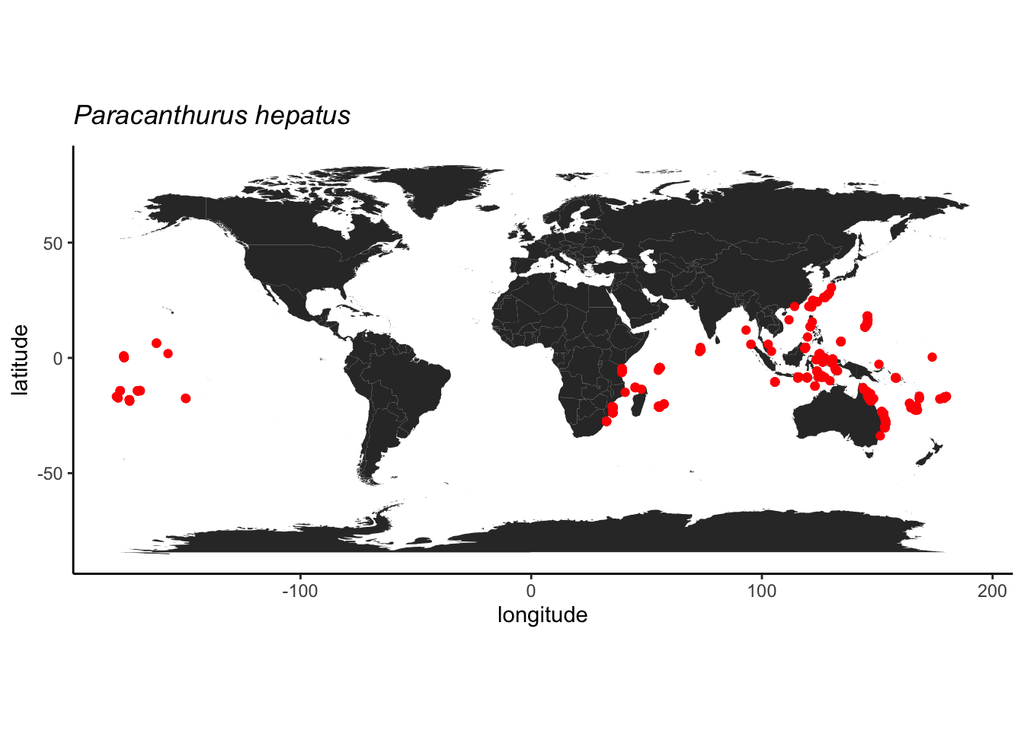

```r
library(ggmap)
library(maps)
library(mapdata)

world <- map_data('world')

# checar pontos

ggplot() +
  geom_polygon(data = world, aes(x = long, y = lat, group = group)) +
  coord_fixed() +
  theme_classic() +
  geom_point(data = dori_gbif_ok, aes(x = decimalLongitude, y = decimalLatitude), color = "red") +
  labs(x = "longitude", y = "latitude", title = expression(italic("Paracanthurus hepatus")))
```

# Profundidade como critério extra

Podemos usar a profundidade como outro critério, pois esta espécie é associada apenas a recifes rasos segundo o FishBase.

Checar profundidade:

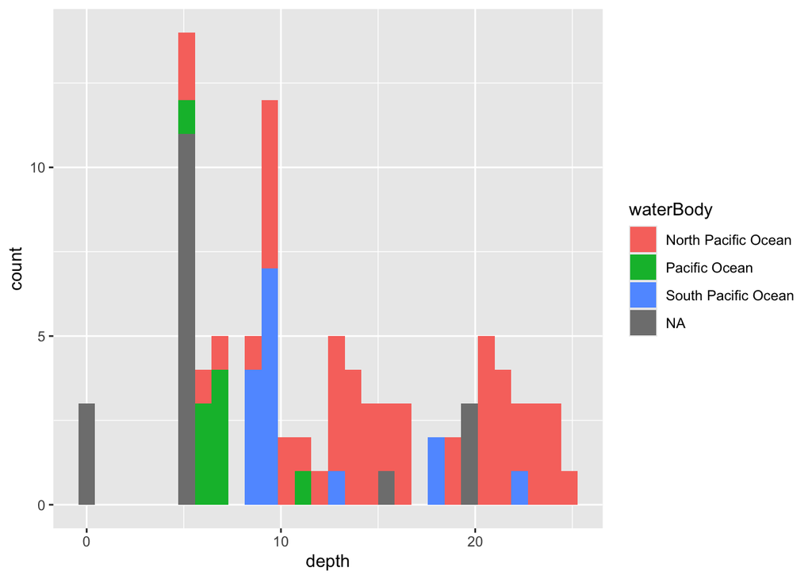

```r
dori_gbif_ok %>%
  ggplot(aes(x = depth, fill = waterBody)) +
    geom_histogram()
```

Parece tudo ok.

# OBIS

Agora vamos fazer os mesmos procedimentos com os dados do OBIS, utilizando o pacote robis e a função occurrence deste pacote.

1. Baixar as ocorrências

```r
## OBIS
dori_obis <- robis::occurrence("Paracanthurus hepatus")
```

```
## Retrieved 581 records of approximately 581 (100%)
```

2. Checar os dados

```r
names(dori_obis)
```

```
##   [1] "basisOfRecord"
##   [2] "brackish"
##   [3] "catalogNumber"
##   [4] "class"
##   [5] "classid"
##   [6] "collectionCode"
##   [7] "country"
##   [8] "datasetID"
##   [9] "date_end"
##  [10] "date_mid"
##  [11] "date_start"
##  [12] "date_year"
##  [13] "day"
##  [14] "decimalLatitude"
##  [15] "decimalLongitude"
```

[output cut: 142 more lines]

Temos variáveis com os mesmos nomes, pois ambos usam o sistema DwC, mas os problemas reportados neste caso são indicados na coluna flags.

```r
dori_obis1 <- dori_obis %>%
  dplyr::select(scientificName, decimalLatitude, decimalLongitude, bathymetry,
         flags, waterBody, basisOfRecord, occurrenceStatus, rightsHolder,
         datasetName, recordedBy, depth, locality, habitat) %>%
  distinct()
```

Checar problemas reportados (flags)

```r
dori_obis1 %>%
  distinct(flags)
```

```
## # A tibble: 6 × 1
##   flags
##   <chr>
## 1 DEPTH_EXCEEDS_BATH,ON_LAND
## 2 NO_DEPTH
## 3 <NA>
## 4 DEPTH_EXCEEDS_BATH
## 5 ON_LAND
## 6 NO_DEPTH,ON_LAND
```

Checar NA em datasetName

```r
dori_obis1 %>%
  filter(!flags %in% c("NO_DEPTH,ON_LAND", "ON_LAND", "DEPTH_EXCEEDS_BATH,ON_LAND"),
         is.na(datasetName)) %>%
  distinct(waterBody)
```

```
## # A tibble: 7 × 1
##   waterBody
##   <chr>
## 1 <NA>
## 2 Pacific Ocean
## 3 WESTERN CENTRAL ATLANTIC
## 4 indien
## 5 Caribbean Sea
## 6 Pacific
## 7 atlantique
```

Aqui usamos as flags para filtrar ocorrências em terra, além de remover dados sem nome de dataset, filtrar ocorrências no Atlântico e verificar a profundidade reportada.

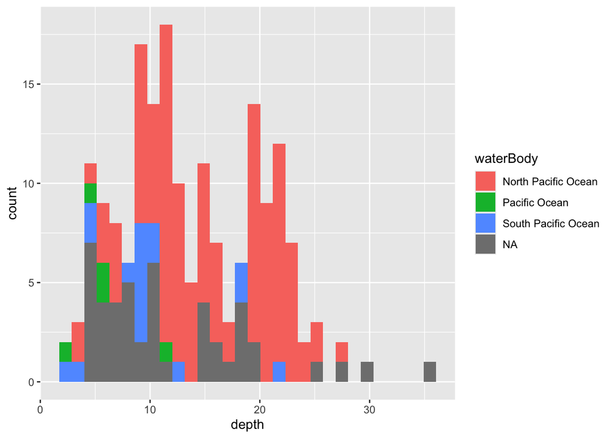

```r
dori_obis1 %>%
  filter(!flags %in% c("NO_DEPTH,ON_LAND", "ON_LAND", "DEPTH_EXCEEDS_BATH,ON_LAND"),
         !is.na(datasetName),
         !waterBody %in% c("Caribbean Sea", "atlantique")) %>%
  ggplot(aes(x = depth, fill = waterBody)) +
    geom_histogram()
```

Checar níveis

```r
dori_obis1 %>%
  filter(!flags %in% c("NO_DEPTH,ON_LAND", "ON_LAND", "DEPTH_EXCEEDS_BATH,ON_LAND"),
         !is.na(datasetName),
         !waterBody %in% c("Caribbean Sea", "atlantique")) %>%
  lapply(., unique)
```

```
## $scientificName
## [1] "Paracanthurus hepatus"
##
## $decimalLatitude
##   [1]  16.4444410  14.9524648  -8.4180000  15.0033074   0.1907412 -12.5814800
##   [7]  16.7105020   0.1970000 -14.1518635  14.9315443  15.1052253 -12.6861843
##  [13]  15.0777326  15.2567141 -14.2852098   0.1908500  21.5893140  -3.7166670
##  [19] -14.2790305  15.1163631  -3.7833333 -12.6720303 -12.9596800  25.0755700
##  [25] -18.1677900  15.2735300  24.4725000   0.1902900  15.1342100  13.2303711
##  [31]  17.5919243  24.5653750 -12.5177000  14.2014619  14.8436598  15.2829550
##  [37]  14.8471569 -12.9600759  18.3372440   0.8224659  14.2460003  15.1924560
##  [43]  15.2766544   0.8208993   0.1868800  15.0520660 -18.1486000  15.2559710
##  [49]  -8.3627887  39.7664250  15.2698445  15.2542167  15.1110520  18.5551160
##  [55] -14.2413730   0.2065500  14.1692040  18.1697050   7.3314750 -18.1718800
##  [61] -15.8160000 -11.6000000  14.8651780  18.0939460 -14.2240685  -8.4156407
```

[output cut: 249 more lines]

Aplicar filtros

```r
# aplicar filtros
dori_obis_ok <- dori_obis1 %>%
  filter(!flags %in% c("NO_DEPTH,ON_LAND", "ON_LAND", "DEPTH_EXCEEDS_BATH,ON_LAND"),
         !is.na(datasetName),
         !waterBody %in% c("Caribbean Sea", "atlantique"))
```

Gráfico

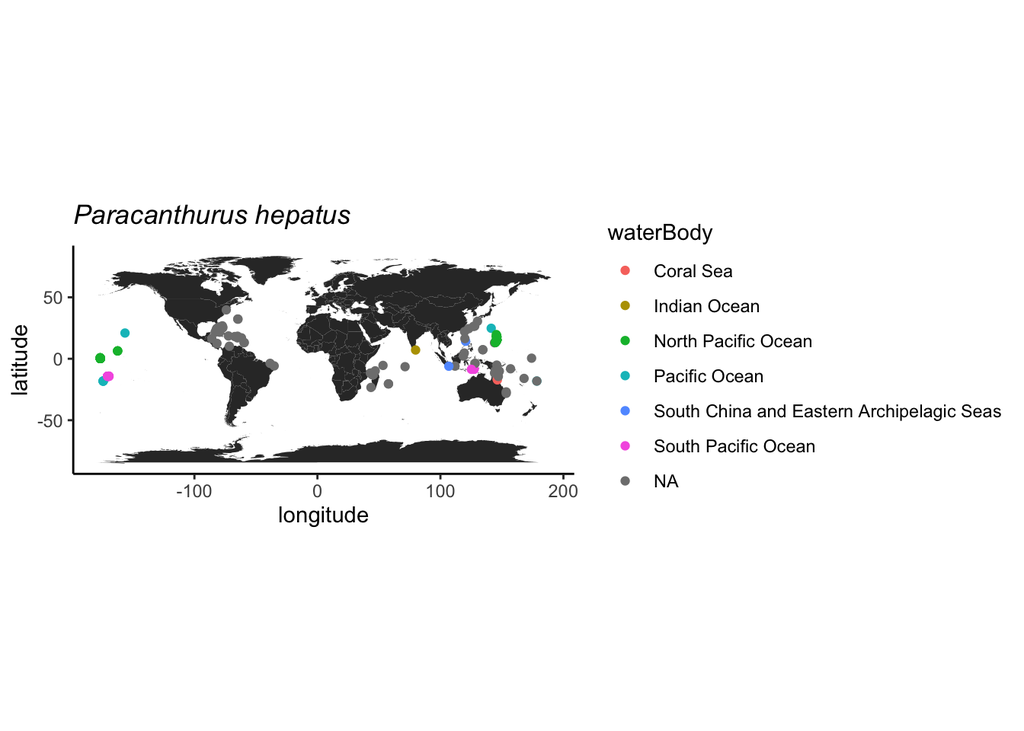

```r
ggplot() +
  geom_polygon(data = world, aes(x = long, y = lat, group = group)) +
  coord_fixed() +
  theme_classic() +
  geom_point(data = dori_obis_ok, aes(x = decimalLongitude, y = decimalLatitude, color = waterBody)) +
  labs(x = "longitude", y = "latitude", title = expression(italic("Paracanthurus hepatus")))
```

Ainda temos ocorrências no Atlântico, então vamos limpar isso e plotar o mapa novamente.

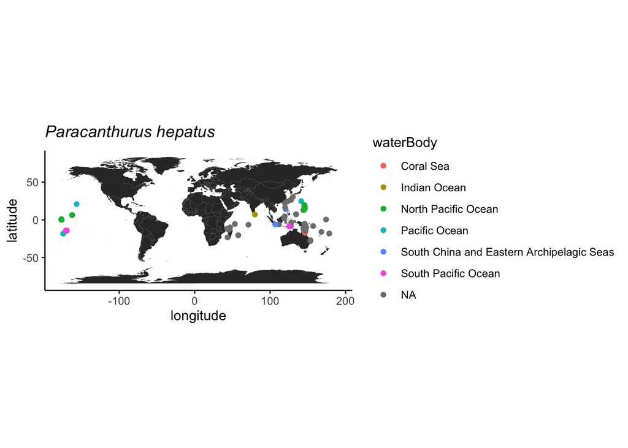

```r
dori_obis_final <- dori_obis_ok %>%
  filter(decimalLongitude > 0 | decimalLongitude < -100)

ggplot() +
  geom_polygon(data = world, aes(x = long, y = lat, group = group)) +
  coord_fixed() +
  theme_classic() +
  geom_point(data = dori_obis_final, aes(x = decimalLongitude, y = decimalLatitude, color = waterBody)) +
  labs(x = "longitude", y = "latitude", title = expression(italic("Paracanthurus hepatus")))
```

Parece tudo ok, e chegamos a 253 ocorrências potenciais.

Por fim, vamos unir todas as ocorrências, checar se existem duplicatas e plotar o resultado final.

# Unir GBIF e OBIS

Ver diferencas entre os dois repositórios:

```r
setdiff(names(dori_gbif_ok), names(dori_obis_ok))
```

```
## [1] "acceptedScientificName" "issues"
```

```r
setdiff(names(dori_obis_final), names(dori_obis_final))
```

```
## character(0)
```

```r
all_data <- bind_rows(dori_gbif_ok %>%
                        mutate(repo = paste0("gbif", row.names(.))),
                      dori_obis_final %>%
                        mutate(repo = paste0("obis", row.names(.)))) %>%
  column_to_rownames("repo") %>%
  dplyr::select(decimalLongitude, decimalLatitude, depth) %>%
  distinct() %>%
  rownames_to_column("occ") %>%
  separate(col = "occ", into = c("datasetName", "rn"), sep = 4) %>%
  mutate(scientificName = "Paracanthurus hepatus") %>%
  dplyr::select(-rn)
```

Mapear ocorrências

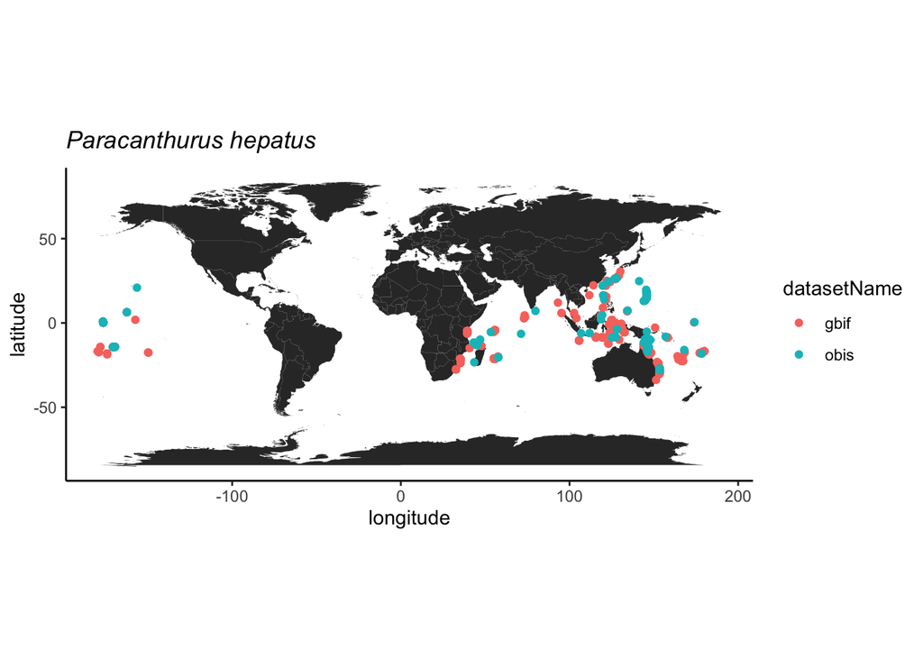

```r
ggplot() +
  geom_polygon(data = world, aes(x = long, y = lat, group = group)) +
  coord_fixed() +
  theme_classic() +
  geom_point(data = all_data, aes(x = decimalLongitude, y = decimalLatitude, color = datasetName)) +
  #theme(legend.title = element_blank()) +
  labs(x = "longitude", y = "latitude", title = expression(italic("Paracanthurus hepatus")))
```

O último passo é guardarmos os dados baixados e tratados para economizar tempo no próximo uso, mas o mais importante já está registrado, o passo-a-passo de como chegamos até os dados usados nas análises.

```r
dir.create("data")
write.csv(all_data, "data/occ_GBIF-OBIS_par_hepa.csv", row.names = FALSE)
```

# EXTRA: Classificação automática de pontos

Função ‘caseira’

Podemos usar outras ferramentas mais refinadas para nos ajudar a detectar ocorrências suspeitas, como as encontradas nos pacotes CoordinateCleaner, obistools, scrubr e biogeo. Além disso, podemos criar nossas próprias funções para auxiliar nessa tarefa.

Abaixo, vamos utilizar os dados baixados do GBIF antes da limpeza já realizada acima.

Aqui vou começar a exemplificar com uma função simples criada por mim. Esta função utiliza as coordenadas para calcular o centróide (ponto médio de todas as ocorrências) e, a partir dele, a distância de cada ponto até o centróide. Esse princípio se baseia em propriedades de conectividade de populações contíguas, então quanto mais distantes (neste caso as muito distantes) maior a chance de termos uma ocorrência suspeita da mesma espécie.

Atenção: isso é apenas uma ferramenta para classificar as ocorrências! A decisão de filtrar ou não os pontos suspeitos vai depender do seu conhecimento ou da literatura a respeito dos habitats e regiões de ocorrência da espécie-alvo.

Inicialmente, vamos carregar a função flag_outlier. E, em seguida, aplicaremos a função e vamos plotar um mapa para avaliar as ocorrências com flag de outlier.

Função para classificar ocorrencias suspeitas

```r
flag_outlier <- function(df, species){


  dados <- df %>%
    dplyr::filter(scientificName == species);

  dados2 <- geosphere::distVincentyEllipsoid(
    dados %>%
      summarise(centr_lon = median(decimalLongitude),
                centr_lat = median(decimalLatitude)),
    dados %>%
      dplyr::select(decimalLongitude, decimalLatitude)
  ) %>%
    bind_cols(dados) %>%
    rename(dist_centroid = '...1') %>%
    mutate(flag = ifelse(dist_centroid < quantile(dist_centroid, probs = 0.90), "OK",
                         ifelse(dist_centroid >= quantile(dist_centroid, probs = 0.90) & dist_centroid < quantile(dist_centroid, probs = 0.95), "check > Q90",
                                ifelse(dist_centroid >= quantile(dist_centroid, probs = 0.95), "check > Q95", "OK"))))

     # mutate(flag = ifelse(dist_centroid > quantile(dist_centroid, probs = prob), "check", "OK"))

  print(dados2)

}
```

Classificar ocorrências

```r
marcados <- dori_gbif$data %>%
  data.frame() %>%
  dplyr::select(scientificName, decimalLongitude, decimalLatitude, datasetName) %>%
  distinct() %>%
  flag_outlier(., species = "Paracanthurus hepatus (Linnaeus, 1766)")
```

```
##     dist_centroid                         scientificName decimalLongitude
## 1       9409578.2 Paracanthurus hepatus (Linnaeus, 1766)        39.384004
## 2       9409293.5 Paracanthurus hepatus (Linnaeus, 1766)        39.386529
## 3       5859005.9 Paracanthurus hepatus (Linnaeus, 1766)        73.373605
## 4       1117146.4 Paracanthurus hepatus (Linnaeus, 1766)       130.715101
## 5       4735285.8 Paracanthurus hepatus (Linnaeus, 1766)       166.440550
## 6       3458998.9 Paracanthurus hepatus (Linnaeus, 1766)       152.708804
## 7        936808.4 Paracanthurus hepatus (Linnaeus, 1766)       116.025881
## 8       4734955.6 Paracanthurus hepatus (Linnaeus, 1766)       166.437320
## 9       9390758.8 Paracanthurus hepatus (Linnaeus, 1766)        39.390292
## 10      4833063.1 Paracanthurus hepatus (Linnaeus, 1766)       168.225762
## 11      7640277.3 Paracanthurus hepatus (Linnaeus, 1766)        55.463104
## 12      4153144.9 Paracanthurus hepatus (Linnaeus, 1766)        93.123434
## 13      3105051.4 Paracanthurus hepatus (Linnaeus, 1766)       111.743646
## 14      3835710.0 Paracanthurus hepatus (Linnaeus, 1766)       153.266930
```

[output cut: 1565 more lines]

Mapa

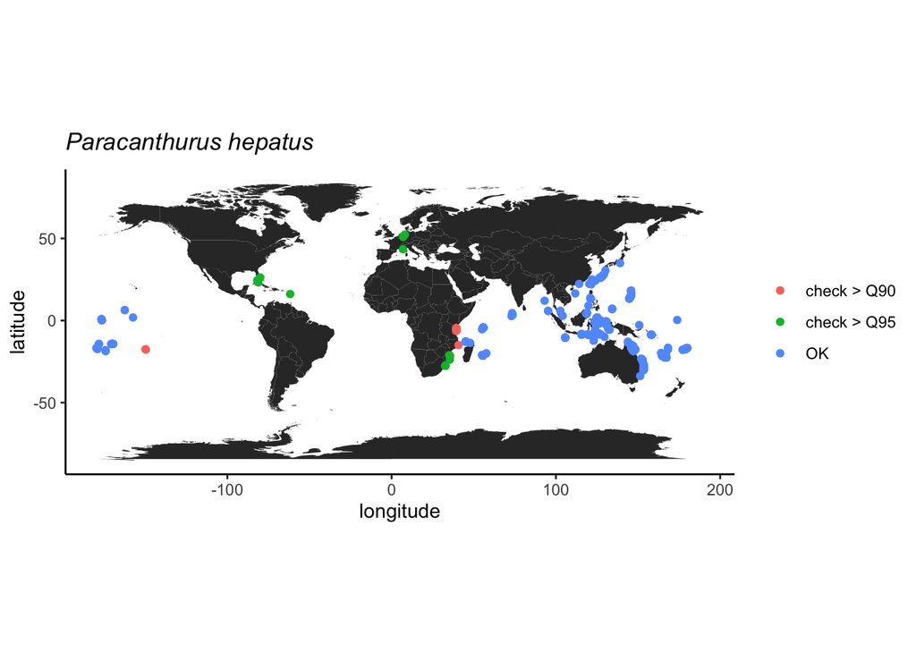

```r
ggplot() +
    geom_polygon(data = world, aes(x = long, y = lat, group = group)) +
    coord_fixed() +
    theme_classic() +
    geom_point(data = marcados,
               aes(x = decimalLongitude, y = decimalLatitude,
                   color = flag)) +
    theme(legend.title = element_blank()) +
    labs(x = "longitude", y = "latitude",
         title = expression(italic("Paracanthurus hepatus")))
```

Podemos notar no mapa acima que as ocorrencias acima do 90ésimo quantil são muito similares às já filtradas acima com base no waterBody, mas se já não tivéssemos a informação da ocorrência restrita da espécie ao Indo-Pacífico, já poderíamos desconfiar destas ocorrências tão longe, os outliers. Investigando o datasetName destas ocorrências com flags também chegaríamos a mesma conclusão de excluir os dados associados ao Diveboard - Scuba diving citizen science e sem valor de datasetName.

Por fim, vamos testar o pacote CoordinateCleaner. Nele devemos especificar os campos correspondentes na função clean_coordinates.

```r
flags <-
  clean_coordinates(
    x = marcados,
    lon = "decimalLongitude",
    lat = "decimalLatitude",
    species = "scientificName",
    tests = c("equal", "gbif",
              "zeros", "seas")
  )
```

```
## Testing coordinate validity
```

```
## Flagged 0 records.
```

```
## Testing equal lat/lon
```

```
## Flagged 0 records.
```

```
## Testing zero coordinates
```

```
## Flagged 0 records.
```

```
## Testing sea coordinates
```

```
## Flagged 367 records.
```

```
## Testing GBIF headquarters, flagging records around Copenhagen
```

```
## Flagged 0 records.
```

```
## Flagged 367 of 394 records, EQ = 0.93.
```

Verificação de outliers:

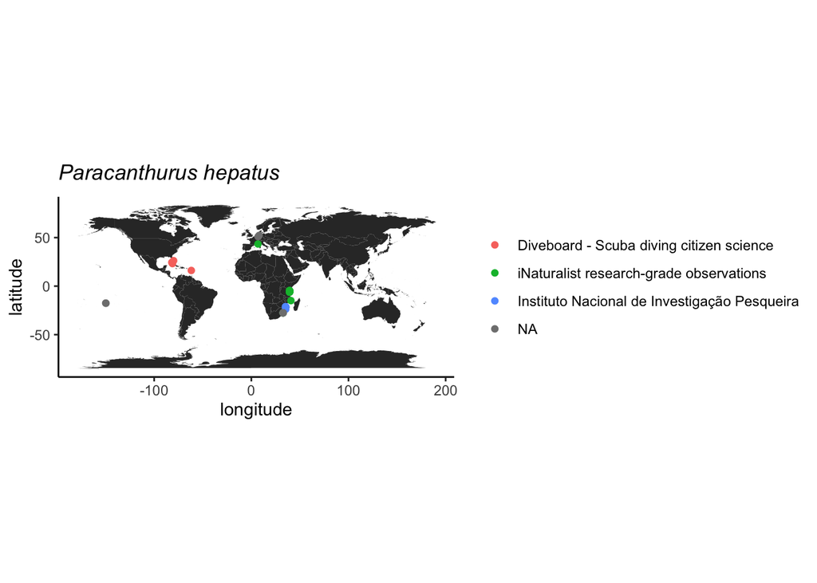

```r
ggplot() +
    geom_polygon(data = world, aes(x = long, y = lat, group = group)) +
    coord_fixed() +
    theme_classic() +
    geom_point(data = marcados %>%
                 filter(flag != "OK"),
               aes(x = decimalLongitude, y = decimalLatitude,
                   color = datasetName)) +
    theme(legend.title = element_blank()) +
    labs(x = "longitude", y = "latitude",
         title = expression(italic("Paracanthurus hepatus")))
```